[figure not shown]

# Overview

**expoFitter** is a specialized tool for visualizing and fitting non-linear electrophysiological data, built using R, Shiny, and Flexdashboard. The tool provides robust methodologies for fitting dynamic processes through single- and double-exponential models, allowing researchers to extract time constants and assess model fitness. Its robust non-linear least squares optimization makes **expoFitter** efficient for fitting complex data.

In scientific applications, **expoFitter**, or its backend logic, has been used to analyze slow neuronal currents like the calcium-dependent potassium current ($I_{KCa}$; Ellison et al., in progress; Thuma et al., in progress). While it does not directly measure intracellular calcium ($[Ca^{2+}]_i$) dynamics, the tool’s modeling logic and resulting uncovered temporal information have been used to indirectly measure $[Ca^{2+}]_i$ time-dependent changes in neurons of the lobster pyloric network, as demonstrated in ongoing research (Ellison et al., in progress; Thuma et al., in progress).

# Tool Features

- **Data Preprocessing and Filtering**: Incorporates a unique data wrangling/filtering algorithm that utilizes both finite and simple differentiation to extract salient parts of the current trace, ensuring accurate and reliable model fits. This preprocessing step is essential for isolating active portions of the current.
- **Native Model Parameter Approximator**: Integrates approximator functionality automating model initial condition estimates based on quintessential features of the experimental data. Given the robustness of the optimizer, this reduces the need for manual adjustment of these parameters by the user.
- **Flexible and Robust Exponential Model Fitting**: Supports both single- and double-exponential model fits using the `nlsLM` algorithm from the `minpack.lm` package. The `nlsLM` algorithm implements the *Levenberg-Marquardt Algorithm*, which combines gradient descent and the Gauss-Newton method for robust non-linear least squares optimization (see Supplemental Information). The application fits experimental data using the following exponential models:
  - **Single-Exponential Model**:

  $$I = A e^{-\frac{t}{B}} + C$$
  - **Double-Exponential Model**:

  $$I = A e^{-\frac{t}{B}} + C
  e^{-\frac{t}{D}} + E$$

  where $B$ and $D$ represent the time constants of the first and second phase of the exponential curve, respectively.
- **Interactive Visualization and Model Parameter Adjustment**: Provides an interactive interface for data visualization and model fitting, enabling users to dynamically adjust model parameters through sliders and observe the resultant model solution both quantitatively and visually.

# Installation

### **expoFitter** Locally

There are several ways to access **expoFitter**. If you want the entirety of the repository, you can clone it to your local machine using these terminal commands (*terminal* used generically throughout):

```bash
git clone https://github.com/ryEllison/expoFitter.git
cd expoFitter
```

Ensure you are in the desired directory before executing the terminal commands. You can also use a point-and-click approach by navigating to *Code* in Github (Figure 1) and selecting *Download ZIP* (Figure 2). Downloading **expoFitter** this way will require your moving **expoFitter** from your local downloads to the desired location on your machine before decompressing the file.

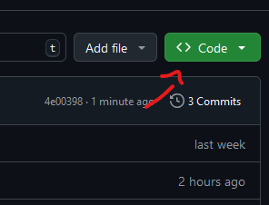

Figure 1. Navigate to Code in Github.

[figure not shown]

Figure 2. Select Download ZIP.

To run **expoFitter** locally, ensure that `R` is installed on your system, as well as the following packages:

- `dplyr 1.1.4`
- `minpack.lm 1.2.4`
- `DT 0.33`
- `shiny 1.9.1`

and your system’s environmental variables provide terminal access to `R`’s interpreter `Rscript`. Package installation is automated and can be completed by running the `install_dependencies` pseudo-executable in the `\bin` directory.

**expoFitter** can then be deployed utilizing your machine as a local server via the `expoFitter_R` pseudo-executable in the `\bin` directory. To make any tweaks or alterations to the tool to fit your particular use case, the code is dispersed throughout appropriate directories (e.g., `\app`, `\scripts`, and `\src`).

### **expoFitter** as Electron App

**expoFitter** has also been built as a portable, desktop `Electron` app. The `Electron` build can be found in the `\electron` directory. However, for access to the desktop app the `\installer` directory can be downloaded using this terminal approach:

```bash
git clone --no-checkout https://github.com/ryEllison/expoFitter.git
cd expoFitter
git sparse-checkout init --cone
git sparse-checkout set ./installer
git checkout master
cd installer
pseudo_installer.bat
```

Again, ensuring you are in the directory where you wish the installer to be placed before executing the terminal commands.

You can also use a point-and-click approach to directly download the installer by navigating to `installer.zip`, clicking the *ellipsis* in the upper right corner (Figure 3), and selecting *Download* (Figure 4; or, using the respective keyboard shortcuts once `installer.zip` has been accessed, e.g., `CTRL + SHIFT + S`). Downloading **expoFitter** this way will require your moving the installer from your local downloads to the desired location on your machine before decompressing the file and executing the `pseudo-installer` pseudo-executable.

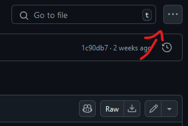

Figure 3. Location of ellipsis option in upper right corner.

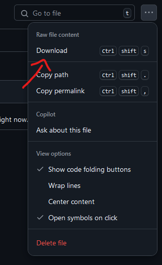

Figure 4. Select Download from ellipsis dropdown.

### **expoFitter** on shinyapps.io

Lastly, **expoFitter** has been made publicly available as a web app, which is hosted on [shinyapps.io](https://www.shinyapps.io/) and can be accessed using https://ryellison.shinyapps.io/expofitter/.

# Usage

### Data Input

- Upload a `.csv` file using `Browse...` under `Select File` containing electrophysiological (e.g., neuronal current) time-series data. Ensure the dataset has *at least* two columns, e.g.,

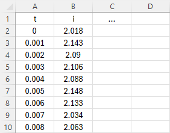

t is time in seconds (s) and i is current data in nanoamps (nA).

- The backend logic of **expoFitter** relies on positional encoding of the data (i.e., utilizes data structure indices for lazy data handling). This, however, makes **expoFitter** more robust in data preparation as column name is inconsequential. All of this is to say, ensure that the dataset is ordered column-wise where the first column contains time data and the second column contains the dynamic process data. If there are more than two columns, column order after the second column is trivial.

### Model Selection and Initialization

- The `Select Model` dropdown menu under `Model Initialization` allows the user to choose between a ‘Single-Exponential,’ ‘Double-Exponential,’ or the implementation of ‘Both’ models.
- The native model parameter approximator auto-estimates initial conditions based on the data and selected model. The sliders can be used to adjust model parameter (`A`, `B`, `C`, `D`, etc.) initial values if the auto-estimated parameters fail.
- The `Fit Model` button must be clicked to run model.

### Visualization, Fitting, and Performance Reporting

- **expoFitter** automatically visualizes the time-series data it ingests.
- Once `Fit Model` is clicked as described above, **expoFitter** will utilize the model parameters auto-estimated or manually selected through alteration of the sliders and then fit the model to the dynamic process using non-linear least squares optimization (see Supplemental Information).
- When the model(s) error minimization is complete, the model fit is visualized in the figure.
- The performance report is provided in the `Model Solution` section, showing the best fit model’s parameters and a quantitative summary of model fitness.

### Saving Results

- When data is uploaded to **expoFitter** the save functionality dynamically appears.
- The user can save the base plot of the electrophysiological data by selecting `Save` before fitting a model.
- Once a model is fit to the data, the figure observed in the `Visualization` section can be saved by clicking the `Save` button in the interface.

All visualizations are saved as a `.pdf` file.

# Related Works

**Ellison, R.**, Thuma, J.B., Hooper, S.L. (in progress). $I_{KCa}$ trajectory reveals extremely slow (seconds-long) $[Ca]_{i}$ removal dynamics in a lobster pyloric neuron.

Thuma, J.B., **Ellison, R.**, Hooper, S.L. (in progress). What slow $I_{KCa}$ reveals about $[Ca]_{i}$ removal dynamics in the lobster pyloric network.

# Supplemental Information

## **Levenberg-Marquardt Algorithm**

Update rule:

$$\mathbf{x}_{k+1} = \mathbf{x}_k - \left(
\mathbf{J}^T \mathbf{J} + \lambda \mathbf{I} \right)^{-1} \mathbf{J}^T
\mathbf{r}$$

Where:

- $\mathbf{J}$ is the Jacobian matrix of the residuals,
- $\mathbf{r}$ is the residual vector (differences between observed and predicted data),
- $\lambda$ is a damping factor that controls the transition between gradient descent (for stability) and the Gauss-Newton method (for faster convergence).

### **Gradient Descent** (when $\lambda$ is large)

Update rule:

$$\mathbf{x}_{k+1} = \mathbf{x}_k - \alpha
\nabla F(\mathbf{x}_k)$$

Where:

- $\alpha$ is the learning rate,
- $\nabla F$ is the gradient of the cost function.

### **Gauss-Newton Method** (when $\lambda$ is small)

Update rule:

$$\mathbf{x}_{k+1} = \mathbf{x}_k - \left(
\mathbf{J}^T \mathbf{J} \right)^{-1} \mathbf{J}^T
\mathbf{r}$$

These methods ensure high-fidelity parameter estimation for complex neuroelectrophysiological datasets.